# STAT605 hw4

Zhuoyan Xu

zxu444

Name: Zhuoyan Xu Email: zxu444@wisc.edu

# Part 1: Leading summary

My procedure is measuring the Euclidean distance. First I standetdized the signal and distance in order to let them have same magnitude. I use distance:
$$\text{dist}(A,B) = \frac{1}{n} \sqrt{\sum_{i=1}^n (A_i - B_i)^2}$$

to measure the difference between signal and noisy. I checked every shift of the signal, i.e. use signal as a filter on every noisy fit with stride 1, and select the most fitted shift for every noisy measurement. I also select the point in noise version whose and_mask is 0, and select the point in corresponding position in signal flux, then compute the distance and conduct the comparison.

For the extension from hw2, I remove the noisy spectrum containing NA. For each of noisy spectrum, when the points whose and_mask is 0 is less than 1/2 of the whole points, I delete the corresponding noisy spectrum.

The procedure works well.

# Part 2: figure of spectra

Load the data:

```r
library(ggplot2)
library('astro')
hwdf = read.csv('hw4best100.csv')
###
cB58 = read.fitstab('cB58_Lyman_break.fit')
files = list.files('download/')
```

Top1:

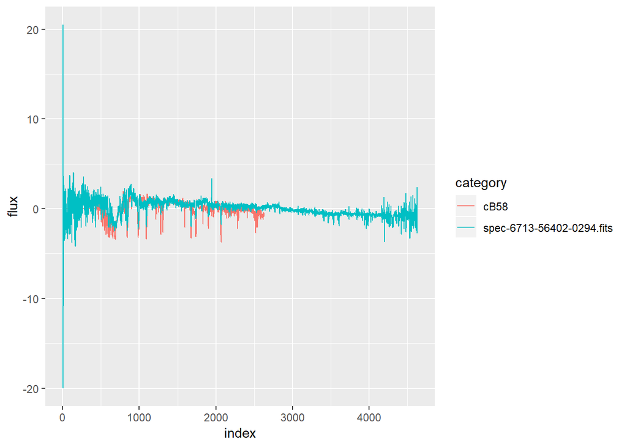

```r
noisy = read.fitstab(paste('download/',hwdf$spectrumID[1],sep = ""))

#plot(scale(noisy[,1]), type = 'l');lines(c(rep(0,519),scale(cB58[,2])),col = 'red')

a = scale(noisy[,1])
b = c(rep(0,hwdf$i[1]-1),scale(cB58[,2]))
df = data.frame(index = c(seq(length(a)),seq(length(b))), flux = c(a,b),
                category = c(rep(as.character(hwdf$spectrumID[1]),length(a)),rep('cB58',length(b))))
ggplot(df,aes(x = index,y = flux)) + geom_line(aes(color = category))
```

Top2:

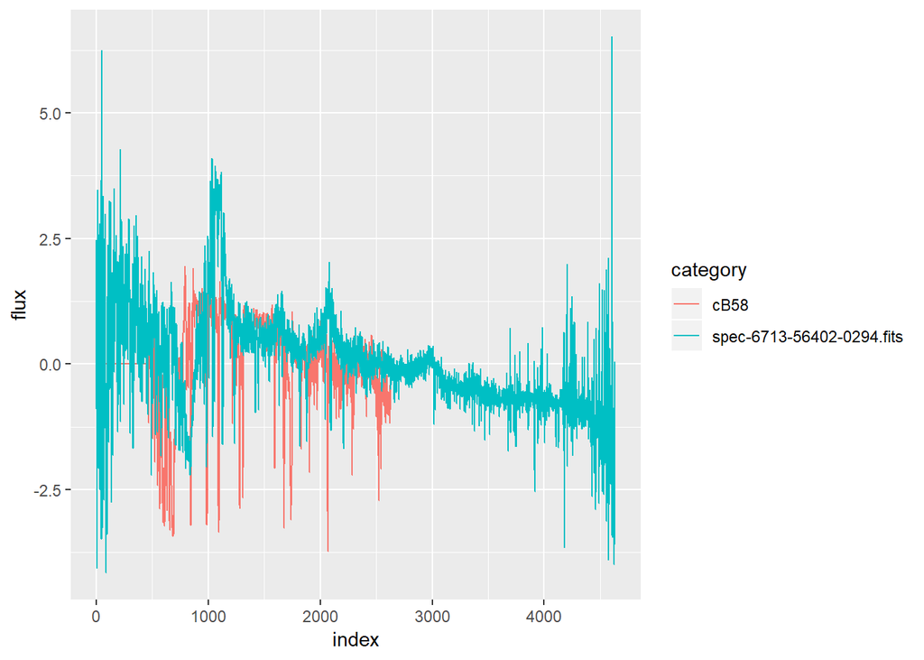

```r
noisy = read.fitstab(paste('download/',hwdf$spectrumID[2],sep = ""))

#plot(scale(noisy[,1]), type = 'l');lines(c(rep(0,519),scale(cB58[,2])),col = 'red')

a = scale(noisy[,1])
b = c(rep(0,hwdf$i[1]-1),scale(cB58[,2]))
df = data.frame(index = c(seq(length(a)),seq(length(b))), flux = c(a,b),
                category = c(rep(as.character(hwdf$spectrumID[1]),length(a)),rep('cB58',length(b))))
ggplot(df,aes(x = index,y = flux)) + geom_line(aes(color = category))
```

Top3:

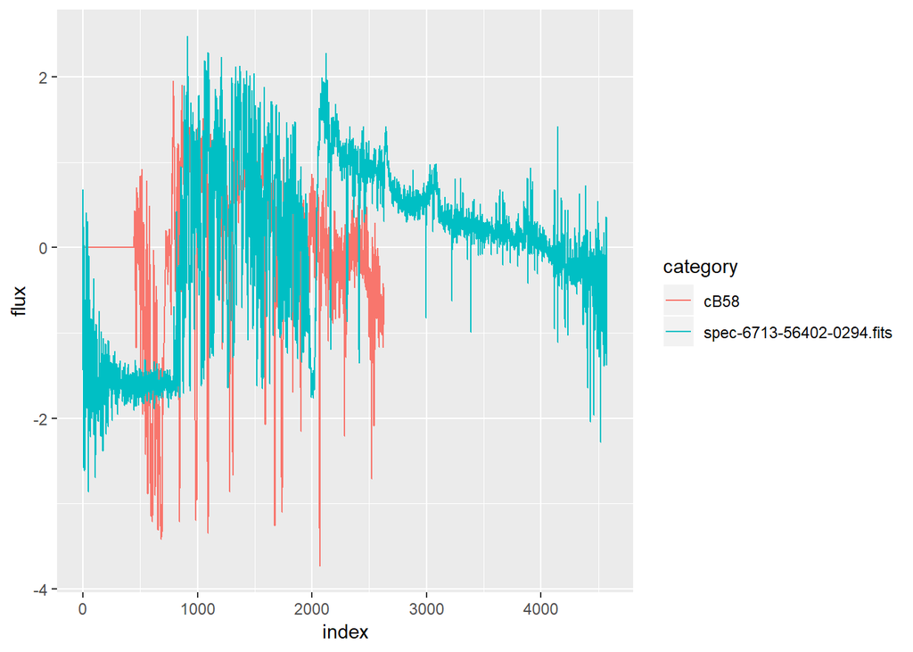

```r
noisy = read.fitstab(paste('download/',hwdf$spectrumID[3],sep = ""))

#plot(scale(noisy[,1]), type = 'l');lines(c(rep(0,519),scale(cB58[,2])),col = 'red')

a = scale(noisy[,1])
b = c(rep(0,hwdf$i[1]-1),scale(cB58[,2]))
df = data.frame(index = c(seq(length(a)),seq(length(b))), flux = c(a,b),
                category = c(rep(as.character(hwdf$spectrumID[1]),length(a)),rep('cB58',length(b))))
ggplot(df,aes(x = index,y = flux)) + geom_line(aes(color = category))
```

Top4:

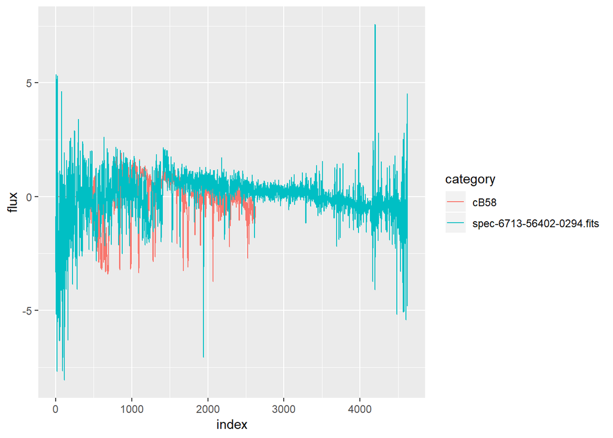

```r
noisy = read.fitstab(paste('download/',hwdf$spectrumID[4],sep = ""))

#plot(scale(noisy[,1]), type = 'l');lines(c(rep(0,519),scale(cB58[,2])),col = 'red')

a = scale(noisy[,1])
b = c(rep(0,hwdf$i[1]-1),scale(cB58[,2]))
df = data.frame(index = c(seq(length(a)),seq(length(b))), flux = c(a,b),
                category = c(rep(as.character(hwdf$spectrumID[1]),length(a)),rep('cB58',length(b))))
ggplot(df,aes(x = index,y = flux)) + geom_line(aes(color = category))
```

Top5:

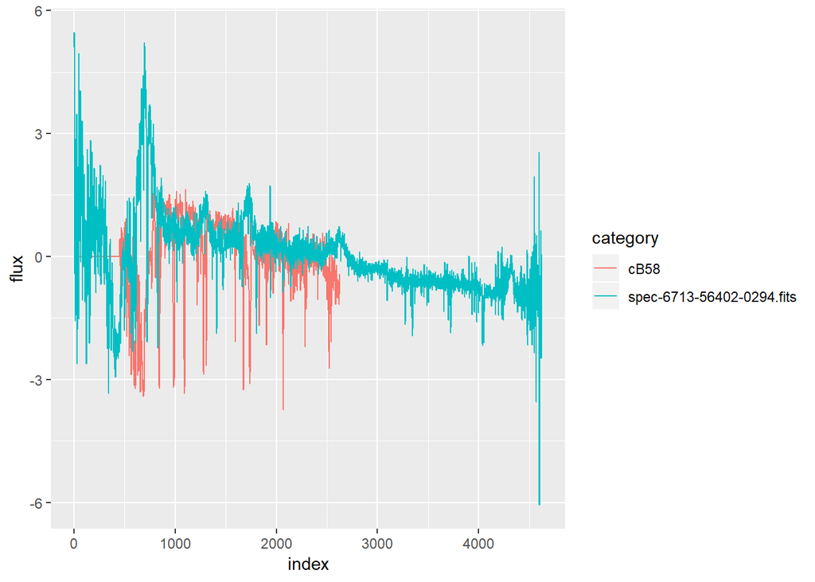

```r
noisy = read.fitstab(paste('download/',hwdf$spectrumID[5],sep = ""))

#plot(scale(noisy[,1]), type = 'l');lines(c(rep(0,519),scale(cB58[,2])),col = 'red')

a = scale(noisy[,1])
b = c(rep(0,hwdf$i[1]-1),scale(cB58[,2]))
df = data.frame(index = c(seq(length(a)),seq(length(b))), flux = c(a,b),
                category = c(rep(as.character(hwdf$spectrumID[1]),length(a)),rep('cB58',length(b))))
ggplot(df,aes(x = index,y = flux)) + geom_line(aes(color = category))
```

Top6:

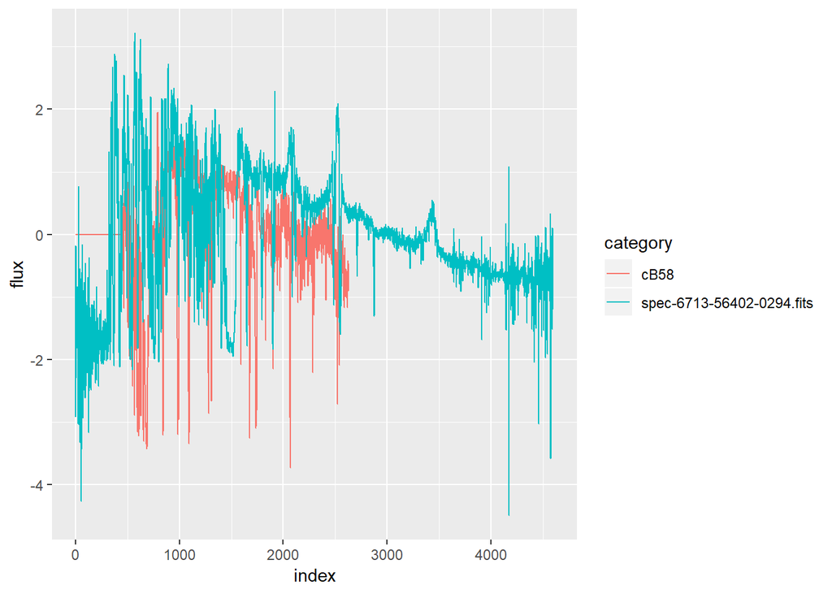

```r
noisy = read.fitstab(paste('download/',hwdf$spectrumID[6],sep = ""))

#plot(scale(noisy[,1]), type = 'l');lines(c(rep(0,519),scale(cB58[,2])),col = 'red')

a = scale(noisy[,1])
b = c(rep(0,hwdf$i[1]-1),scale(cB58[,2]))
df = data.frame(index = c(seq(length(a)),seq(length(b))), flux = c(a,b),
                category = c(rep(as.character(hwdf$spectrumID[1]),length(a)),rep('cB58',length(b))))
ggplot(df,aes(x = index,y = flux)) + geom_line(aes(color = category))
```

Top7:

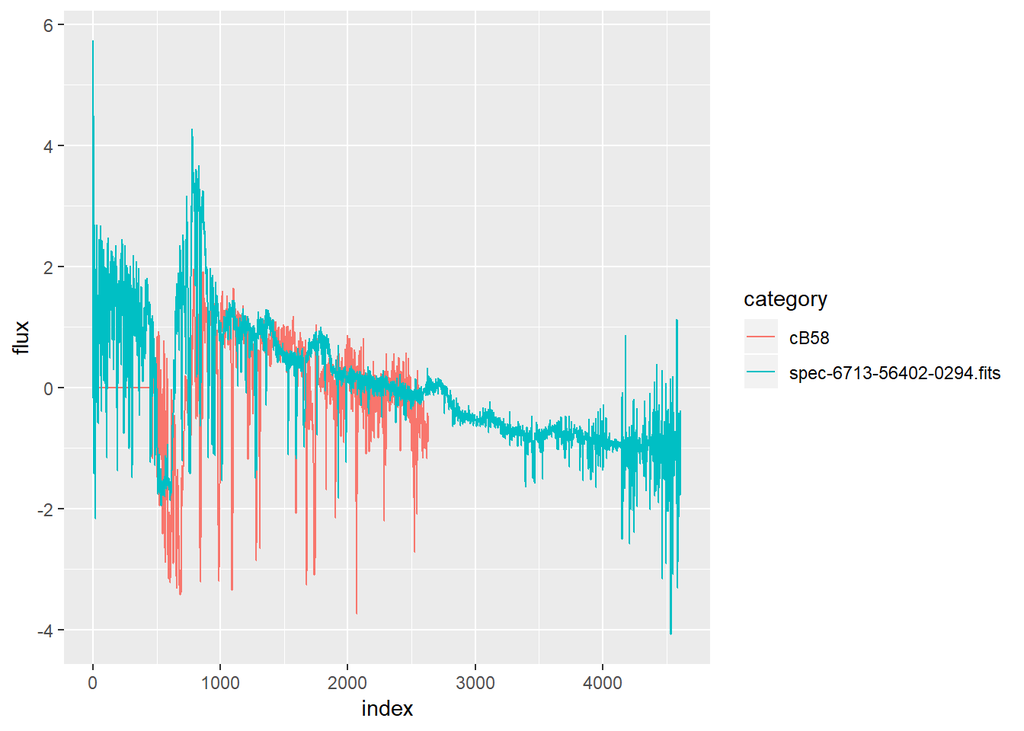

```r
noisy = read.fitstab(paste('download/',hwdf$spectrumID[7],sep = ""))

#plot(scale(noisy[,1]), type = 'l');lines(c(rep(0,519),scale(cB58[,2])),col = 'red')

a = scale(noisy[,1])
b = c(rep(0,hwdf$i[1]-1),scale(cB58[,2]))
df = data.frame(index = c(seq(length(a)),seq(length(b))), flux = c(a,b),
                category = c(rep(as.character(hwdf$spectrumID[1]),length(a)),rep('cB58',length(b))))
ggplot(df,aes(x = index,y = flux)) + geom_line(aes(color = category))
```

Top8:

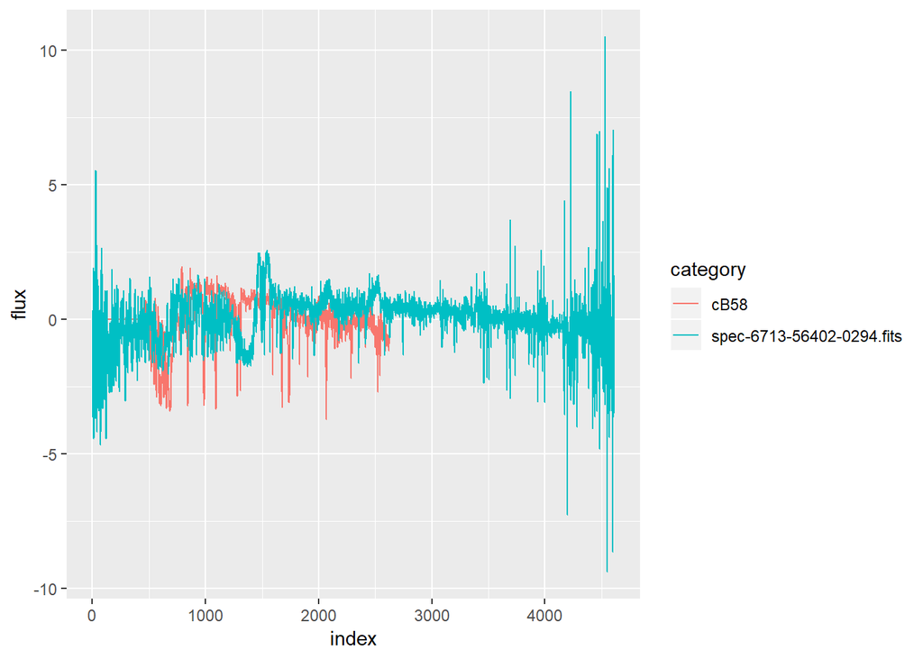

```r
noisy = read.fitstab(paste('download/',hwdf$spectrumID[8],sep = ""))

#plot(scale(noisy[,1]), type = 'l');lines(c(rep(0,519),scale(cB58[,2])),col = 'red')

a = scale(noisy[,1])
b = c(rep(0,hwdf$i[1]-1),scale(cB58[,2]))
df = data.frame(index = c(seq(length(a)),seq(length(b))), flux = c(a,b),
                category = c(rep(as.character(hwdf$spectrumID[1]),length(a)),rep('cB58',length(b))))
ggplot(df,aes(x = index,y = flux)) + geom_line(aes(color = category))
```

Top9:

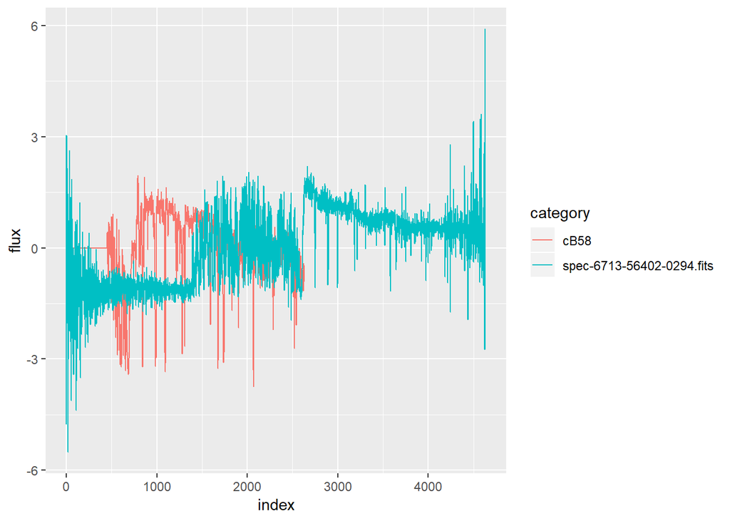

```r
noisy = read.fitstab(paste('download/',hwdf$spectrumID[9],sep = ""))

#plot(scale(noisy[,1]), type = 'l');lines(c(rep(0,519),scale(cB58[,2])),col = 'red')

a = scale(noisy[,1])
b = c(rep(0,hwdf$i[1]-1),scale(cB58[,2]))
df = data.frame(index = c(seq(length(a)),seq(length(b))), flux = c(a,b),
                category = c(rep(as.character(hwdf$spectrumID[1]),length(a)),rep('cB58',length(b))))
ggplot(df,aes(x = index,y = flux)) + geom_line(aes(color = category))
```

Top10:

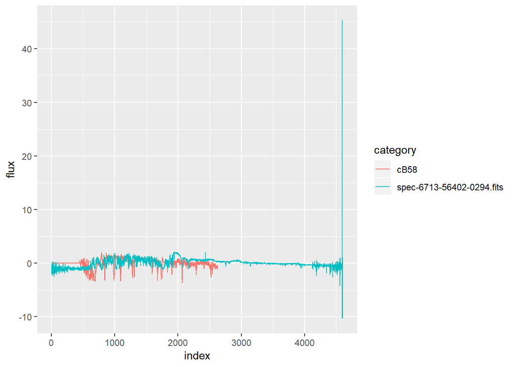

```r
noisy = read.fitstab(paste('download/',hwdf$spectrumID[10],sep = ""))

#plot(scale(noisy[,1]), type = 'l');lines(c(rep(0,519),scale(cB58[,2])),col = 'red')

a = scale(noisy[,1])
b = c(rep(0,hwdf$i[1]-1),scale(cB58[,2]))
df = data.frame(index = c(seq(length(a)),seq(length(b))), flux = c(a,b),
                category = c(rep(as.character(hwdf$spectrumID[1]),length(a)),rep('cB58',length(b))))
ggplot(df,aes(x = index,y = flux)) + geom_line(aes(color = category))
```